# Vector valued functions

We discuss functions of a single variable that return a vector in $R^n$. There are many parallels to univariate functions (when $n=1$).

## Definition

A function $\vec{f}: R \rightarrow R^n, n > 1$ is called a vector valued function. Some examples:

$$~ \vec{f}(t) = \langle \sin(t), 2\cos(t) \rangle, \quad \vec{g}(t) = \langle \sin(t), \cos(t), t \rangle, \quad \vec{h}(t) = \langle 2, 3 \rangle + t \cdot \langle 1, 2 \rangle. ~$$

The components them selves are also functions of $t$, in this case univariate functions. Depending on the context, it can be useful to view these as a function that returns a vector, or a vector of the component functions.

The above example functions have $n$ equal $2$, $3$, and $2$ respectively. We will see that many concepts of calculus for univariate functions ($n=1$) have direct counterparts.

## Representation in Julia

In `Julia`, the representation of a vector valued function is straightforward: we define a function of a single variable that returns a vector. For example, the three functions above would be represented by:

```julia
f(t) = [sin(t), 2*cos(t)]
g(t) = [sin(t), cos(t), t]
h(t) = [2, 3] + t * [1, 2]
```

```
h (generic function with 1 method)
```

For a given `t`, these evaluate to a vector. For example:

```julia
h(2)
```

```
2-element Array{Int64,1}:
 4
 7
```

We can create a vector of functions, e.g. `F = [cos, sin, identify]` but calling this object, as in `F(t)` would require some work, such as `t = 1; [f(t) for f in F]`.

## Space curves

A vector-valued function is typically visualized as a parameterized curve. That is, for some range, $a \leq t \leq b$ the set of points $\{\vec{f}(t): a \leq t \leq b\}$ are plotted. That is, if, say in $n=2$, we have $x(t)$ and $y(t)$ as the component functions, then the graph would also be the parametric plot of $x$ and $y$.

This plot represents the vectors with their tails at the origin.

There is a convention for plotting the component functions to yield a parametric plot within the `Plots` package (e.g., `plot(x, y, a, b)`) but we will use a different approach, as the component functions are not naturally produced from the vector-valued function.

In `Plots`, the command `plot(xs, ys)`, where, say, `xs=[x1, x2, ..., xn]` and `ys=[y1, y2, ..., yn]`, will make a connect-the-dot plot between corresponding pairs of points. Similarly, were a third vector, `zs`, for $z$ components used. However, naturally can generate the vector of points: `[[x1,y1], [x2, y2], ..., [xn, yn]]`, as this comes from broadcasting `f` over some time values. That is, for collection of time values, `ts`, as typically generated by `range`, the command `f.(ts)` will produce the vector of points.

To get the `xs` and `ys` from this, is conceptually easy: just iterate of all the points and extract the corresponding component. E.g, to get `xs` we would have a command like `[p[1] for p in f.(ts)]`. Similarly, the `ys` would use `p[2]` in place of `p[1]`. The following function does this for us, returning the vectors in a tupleL

```julia
xs_ys(vs) = Tuple(eltype(vs[1])[vs[i][j] for i in 1:length(vs)] for j in eachindex(first(vs)))
```

```
xs_ys (generic function with 1 method)
```

We define a few convenience functions, the first allows us to pass the vector of vectors entry by entry, the latter creates the values `f.(ts)` first from a specification of the interval `[a,b]` and the number of points, with a default of 100:

```julia
xs_ys(v,vs...) = xs_ys([v, vs...])
xs_ys(r::Function, a, b, n=100) = xs_ys(r.(range(a, stop=b, length=n)))
```

```
xs_ys (generic function with 4 methods)
```

```julia
function arrow!(plt::Plots.Plot, p, v; kwargs...)
  length(p) == 2 && return quiver!(plt, xs_ys([p])..., quiver=Tuple(xs_ys([v])); kwargs...)
  length(p) == 3 && return plot!(plt, xs_ys(p, p+v)...; kwargs...)
end
arrow!(p, v; kwargs...) = arrow!(Plots.current(), p, v; kwargs...)
```

```
arrow! (generic function with 2 methods)
```

With these definitions, we can visualize the three functions we have defined.

Here we show the plot of `f` over the values between $0$ and $2\pi$ and also add a vector anchored at the origin defined by `f(1)`.

```julia
using Plots
plot(xs_ys(f, 0, 2pi)...)
arrow!([0,0], f(1))
```

[output not shown]

The trace of the plot is an ellipse. If we describe the components as $\vec{f}(t) = \langle x(t), y(t) \rangle$, then we have $x(t)^2 + y(t)^2/4 = 1$. That is, for any value of $t$, the resulting point satisfies the equation $x^2 + y^2/4 =1$ for an ellipse.

The plot of $g$ needs 3-dimensions to render. For most plotting backends, the following should work with no differences, save the additional vector is anchored in 3 dimensions now:

```julia
plot(xs_ys(g, 0, 6pi)...)
arrow!([0,0, 0], g(1))
```

[output not shown]

Here the graph is a helix; three turns are plotted. If we write $g(t) = \langle x(t), y(t), z(t) \rangle$, as the $x$ and $y$ values trace out a circle, the $z$ value increases. Were the graph viewed from above, we would only see the $x$ and $y$ components, and the view would be circular.

The graph of $h$ shows that this function parameterizes a line in space. The line segment for $-2 \leq t \leq 2$ is shown below:

```julia
plot(xs_ys(h, -2, 2)...)
```

[output not shown]

##### Example

The Spirograph is "... a geometric drawing toy that produces mathematical roulette curves of the variety technically known as hypotrochoids and epitrochoids. It was developed by British engineer Denys Fisher and first sold in 1965." These can be used to make interesting geometrical curves.

The center of the inner circle moves with radius $R-r$. Let $\tilde{r} = R/r - 1$. Relative to that the fixed point on the inner circle will follow this superposition:

$$~ \vec{f}(t) = (R-r) \langle \cos(t), \sin(t) \rangle + \rho \langle \cos(\frac{R-r}{r}t), -\sin(\frac{R-r}{r}t) \rangle. ~$$

We can graph an example, as follows:

```julia
R, r = 25, 5
rho = 0.8*r

f(t) = (R-r)*[cos(t), sin(t)] + rho * [cos((R-r)/r * t), -sin((R-r)/r * t)]

plot(xs_ys(f, 0, 2pi, 1000), aspect_ratio=:equal)
```

[output not shown]

##### Example

And the motion relative to the origin would be the vector sum, or superposition:

$$~ \vec{f}(t) = \vec{u}(t) + \vec{v}(t). ~$$

To visualize for some parameters, we have:

```julia
R, r = 25, 5
height = 5
S, T = 8, 2
u(t) = [R * sin(2pi*t/T), R * cos(2pi*t/T), height*(1 +sin(2pi * t/T))]
v(t) = [r * sin(2pi*t/S), r * cos(2pi*t/S), 0]
f(t) = u(t) + v(t)
plot(xs_ys(f, 0, 8, 1000)...)
```

[output not shown]

## limits

The definition of a limit for a univariate function is: For every $\epsilon > 0$ there exists a $\delta > 0$ such that *if* $0 \leq |x-c| < \delta$ *then* $|f(x) - L | < \epsilon$.

If this the notion of $f$ is close to $L$ is replaced by close in the sense of a norm, then the same limit definition can be used, with the new wording "... $\| \vec{f}(x) - L \| < \epsilon$".

A consequence of the triangle inequality is that a vector-valued function is continuous if and only it its component functions are.

## derivatives

If $\vec{f}(t)$ is vector valued, and $\Delta t > 0$ then we can consider the vector:

$$~ \vec{f}(t + \Delta t) - \vec{f}(t) ~$$

For example, if $\vec{f}(t) = \langle \sin(t), 3\cos(t) \rangle$ and $t=\pi/4$ and $\Delta t = \pi/16$ we have this picture:

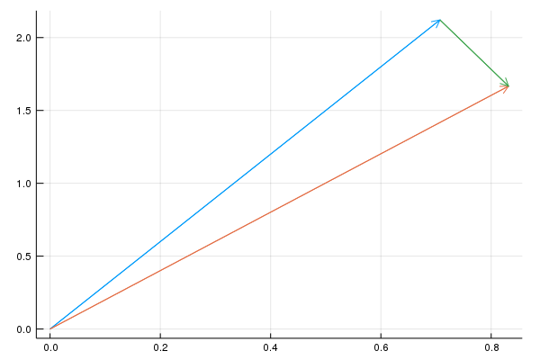

```julia
gr()
f(t) = [sin(t), 3cos(t)]
t, Deltat = pi/4, pi/16
df = f(t + Deltat) - f(t)
plot(legend=false)
arrow!([0,0], f(t))
arrow!([0,0], f(t+Deltat))
arrow!(f(t), df)
```

The length of the difference appears to be related to the length of $\Delta t$, in a similar manner as the univariate derivative. The following limit defines the *derivative* of a vector-valued function:

$$~ \vec{f}'(t) = \lim_{\Delta t \rightarrow 0} \frac{f(t + \Delta t) - f(t)}{\Delta t}. ~$$

The limit exists if the component limits do. The component limits are just the derivatives of the component functions. So, if $\vec{f}(t) = \langle x(t), y(t) \rangle$, then $\vec{f}'(t) = \langle x'(t), y'(t) \rangle$.

The derivative is a tangent vector to the parameterized curve, akin to the case for a univariate function. We can use `ForwardDiff` to compute derivative in the exact same manner as was done for univariate functions:

```julia
using ForwardDiff
D(f,n=1) = n > 1 ? D(D(f),n-1) : x -> ForwardDiff.derivative(f, x)
Base.adjoint(f::Function) = D(f)         # allow f' to compute derivative
```

We can visualize the tangential property through a graph:

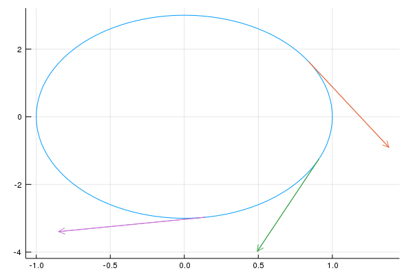

```julia
f(t) = [sin(t), 3cos(t)]
p = plot(xs_ys(f, 0, 2pi)..., legend=false)
for t in [1,2,3]
    arrow!(p, f(t), f'(t))   # add arrow with tail on curve, in direction of derivative
end
p
```

### Symbolic representation

Were symbolic expressions used in place of functions, the vector-valued function would naturally be represented as a vector of expressions:

```julia
using SymPy
@vars t
vvf = [sin(t), cos(t), t]
```

\[ \left[ \begin{array}{r}\sin{\left (t \right )}\\\cos{\left (t \right )}\\t\end{array} \right] \]

We will see working with these expressions is not idential to working with a vector-valued function.

To plot, we can avail ourselves of the the parametric plot syntax. The following expands to `plot(sin(t), cos(t), t, 0, 2pi)`:

[figure not shown]

```julia
plot(vvf..., 0, 2pi)
```

The `xs_ys` usage, as was done above, could be used, but it would be much more trouble in this case.

To evalute the function at a given value, say $t=2$, we can use `subs` with broadcasting to substitute into each component:

```julia
subs.(vvf, t.=>2)
```

\[ \left[ \begin{array}{r}\sin{\left (2 \right )}\\\cos{\left (2 \right )}\\2\end{array} \right] \]

The notation is a bit subtle: `subs.(` will broadcast over the 3 components in `vvf`. This is familiar, but broadcasting tries to match up sizes of collections. Without a "dot", `vvf` would have size 3 and `t=>2` has size 2 as an iterable object; and this causes a mismatch. We need to make `t=>2` appear to have just length 1. The `t.=>2` expresses this, also would wrapping in a tuple, as in `(t=>2, )` or using `Ref`, as in `Ref(t=>2)` would have worked.

Limits are performed component by component, and can also be defined by broadcasting, again with the need to adjust the values:

```julia
@syms delta
limit.((subs.(vvf, t .=> t + delta) - vvf) / delta, delta .=> 0)
```

\[ \left[ \begin{array}{r}\cos{\left (t \right )}\\- \sin{\left (t \right )}\\1\end{array} \right] \]

Derivatives, as was just done through a limit, are a bit more straightforward than evaluation or limit taking, as we won't bump into the shape mismatch:

```julia
diff.(vvf, t)
```

\[ \left[ \begin{array}{r}\cos{\left (t \right )}\\- \sin{\left (t \right )}\\1\end{array} \right] \]

If these differences are too subtle, it might be best to work with a function and when a symbolic expression is desirable, simply evaluate the function for a symbolic value.

### Applications of the derivative

The derivative of a vector valued function is similar to that of a univariate function, in that it indicates a direction tangent to a curve. To parameterize this line uses the point-slope form. We have a point given through the vector-valued function and a direction given by its derivative. (After identifying a vector with its tail at the origin with the point that is the head of the vector.)

With this, the equation is simply $\vec{tl}(t) = \vec{f}(t_0) + \vec{f}'(t_0) \cdot (t - t_0)$, where the dot indicates scalar multiplication.

##### Example: tractrix

A [tractrix](https://en.wikipedia.org/wiki/Tractrix), studied by Perrault, Newton, Huygens, and many others, is the curve along which an object moves when pulled in a horizontal plane by a line segment attached to a pulling point (Wikipedia). If the object is placed at $(a,0)$ and the puller at the origin, and the puller moves along the positive $x$ axis, then the line will always be tangent to the curve and of fixed length, so determinable from the motion of the puller. In this example $dy/dx = -\sqrt{a^2-x^2}/x$.

This is the key property: "Due to the geometrical way it was defined, the tractrix has the property that the segment of its tangent, between the asymptote and the point of tangency, has constant length $a$."

As a bicyle moves, the motion of the rear wheel relative to the front is a fixed length and such that the direction of motion of the rear wheel points to the front wheel. That is, the paths follow a tractrix. If we start with the rear wheel (the object) above, we can readily describe the curve for the front wheel by plotting the tangent line with length 1.

For example, if the rear wheel moves according to the following parametric equation, we can plot both the rear wheel and the front wheel:

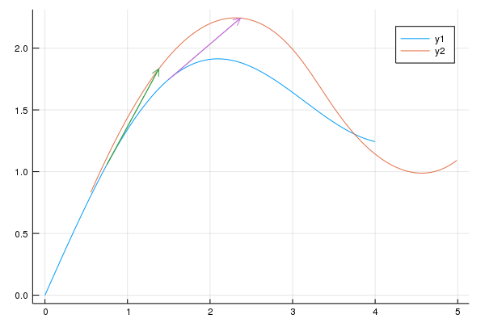

```julia
using LinearAlgebra
a, b = 0, 4
t1, t2 = 3/4, 3/2
rw(t) = [t, t/2 + sin(t)]
plot(xs_ys(rw, a, b,1000)...)

uvec(v) = v/norm(v)

fw(t) = rw(t) + uvec(rw'(t))
plot!(xs_ys(fw, a, b,1000)...)

arrow!(rw(t1), uvec(rw'(t1)))
arrow!(rw(t2), uvec(rw'(t2)))
```

### Derivative rules.

Clearly from the definition, it should be clear that for vector-valued functions $\vec{f}, \vec{g}: R \rightarrow R^n$ we would have:

$$~ [\vec{f} + \vec{g}]'(t) = \vec{f}'(t) + \vec{g}'(t), \quad\text{and } [a\vec{f}]'(t) = a \vec{f}'(t). ~$$

If $s$ is a univariate function, then the composition $\vec{f}(s(t))$ can be differentiated. Each component would satisfy the chain rule, and consequently:

$$~ \frac{d}{dt}\left(\vec{f}(s(t))\right) = \vec{f}'(s(t)) \cdot s'(t), ~$$

The dot being scalar multiplication by the derivative of the univariate function $s$.

Vector valued functions do not have multiplication or division defined for them, so there are no ready analogues of the product and quotient rule. However, the dot product and the cross product produce new functions that may have derivative rules available.

For the dot product, the combination $\vec{f}(t) \cdot \vec{g}(t)$ we have a univariate function of $t$, so we know a derivative is well defined. Can it be represented in terms of the vector-valued functions? In terms of the component functions, we have this calculuation specific to $n=2$, but that which can be generalized:

$$~ \frac{d}{dt}(\vec{f}(t) \cdot \vec{g}(t)) = \frac{d}{dt}(f_1(t) g_1(t) + f_2(t) g_2(t)) = f_1'(t) g_1(t) + f_1(t) g_1'(t) + f_2'(t) g_2(t) + f_2(t) g_2'(t) = f_1'(t) g_1(t) + f_2'(t) g_2(t) + f_1(t) g_1'(t) + f_2(t) g_2'(t) = \vec{f}'(t)\cdot \vec{g}(t) + \vec{f}(t) \cdot \vec{g}'(t). ~$$

Suggesting the that a product rule like formula applies for dot products.

For the cross product, we let `SymPy` derive a formula for us.

```julia
@symfuns u1 u2 u3 v1 v2 v3
@vars t
u = [u1(t), u2(t), u3(t)]
v = [v1(t), v2(t), v3(t)]
```

[output not shown]

```julia
using LinearAlgebra
diff.(u × v, t)
```

[output not shown]

```julia
diff.(u × v, t) - (diff.(u,t) × v + u × diff.(v,t))
```

[output not shown]

##### Application. Circular motion and the tangent vector.

The parameterization $\vec{r}(t) = \langle \cos(t), \sin(t) \rangle$ describes a circle. Characteristic of this motion is a constant radius, or in terms of a norm: $\| \vec{r}(t) \| = c$. The norm squared, can be expressed in terms of the dot product:

$$~ \| \vec{r}(t) \|^2 = \vec{r}(t) \cdot \vec{r}(t). ~$$

Differentiating this for the case of a constant radius yields the equation $0 = [\vec{r}\cdot\vec{r}]'(t)$, which simplifies through the product rule to $0 = 2 \vec{r}(t) \cdot \vec{r}'(t)$. That is, the two vectors are perpendicular to each other.

### T, B, N

## curvature, torsion

## Arc length